# Tipología y ciclo de vida de los datos

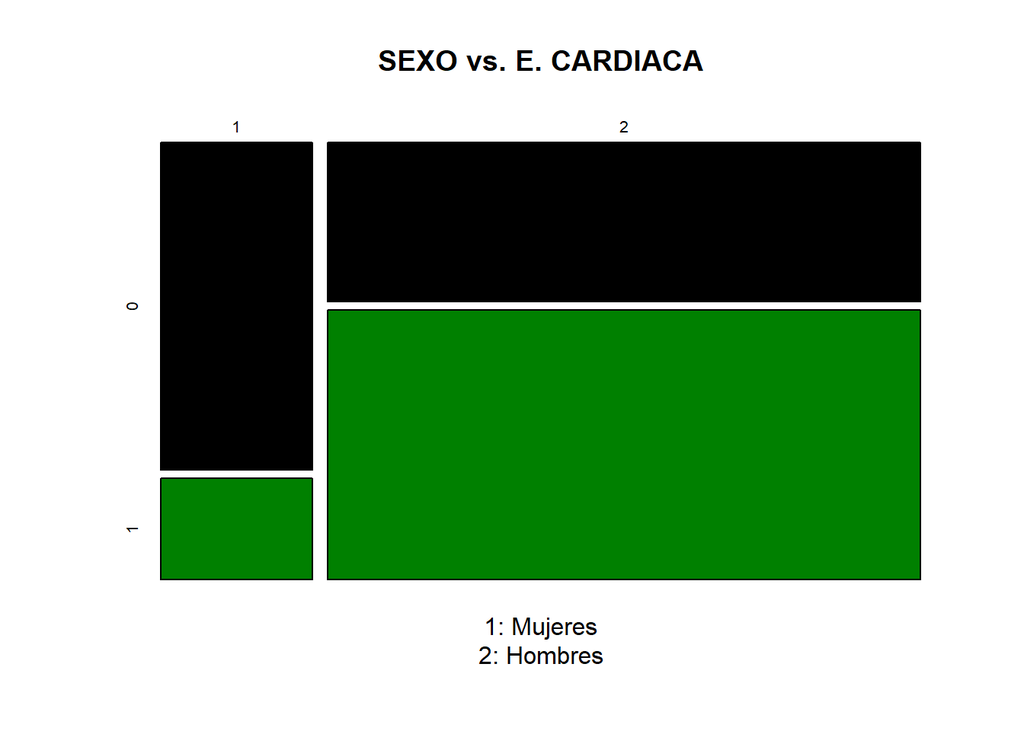

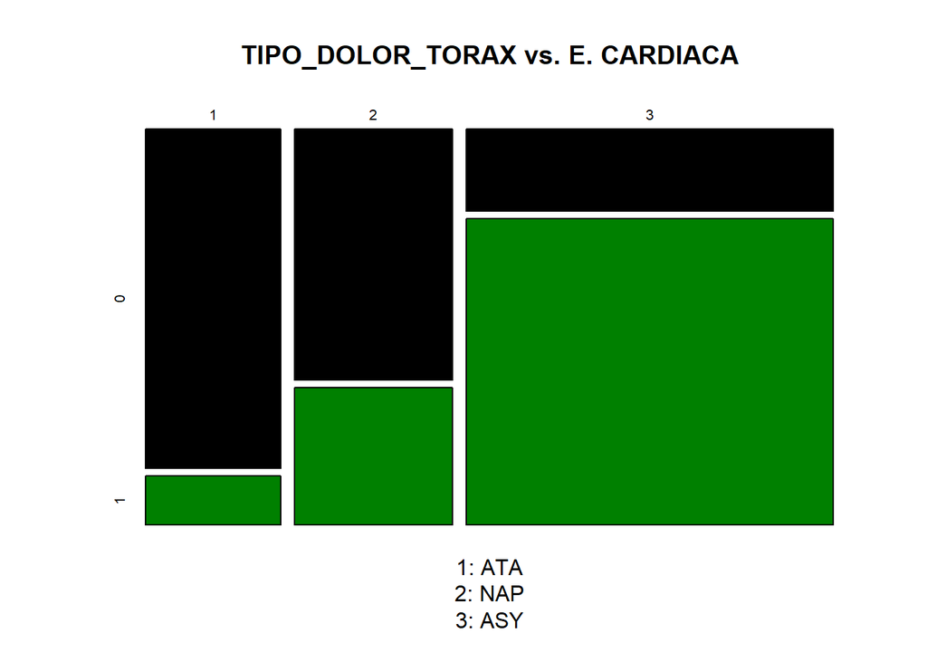

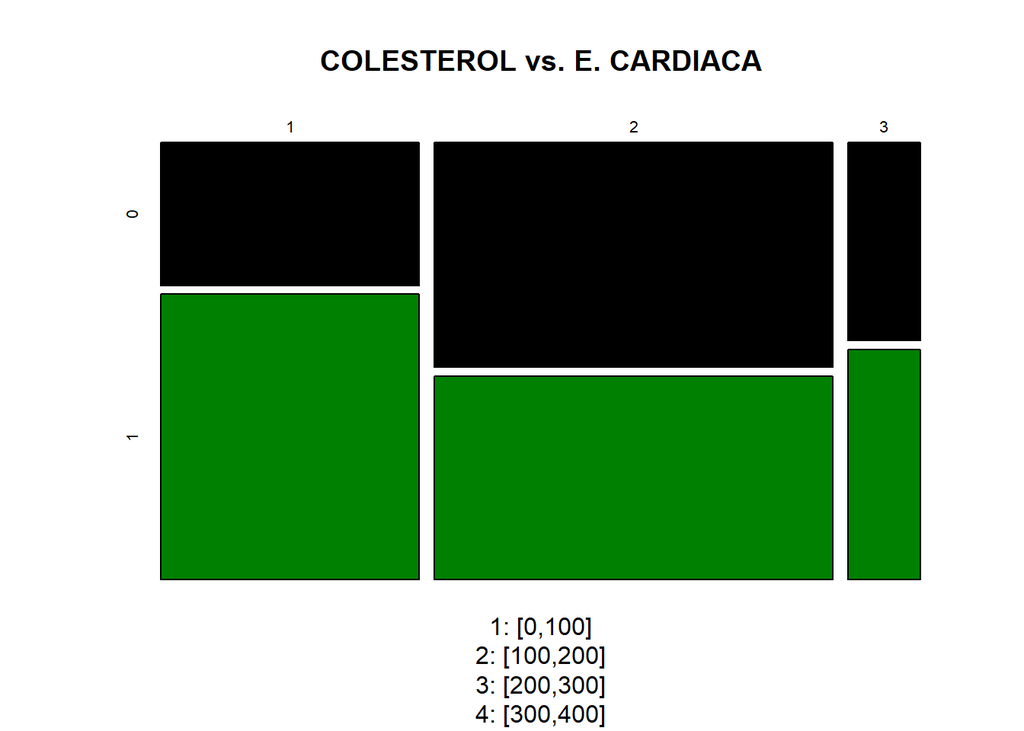

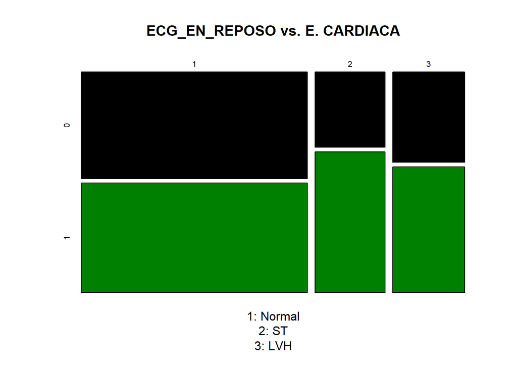

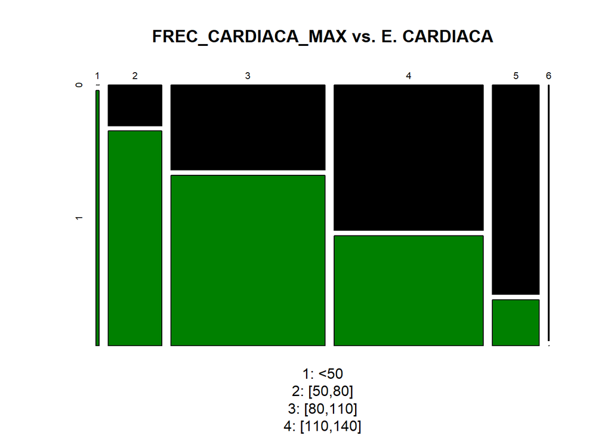

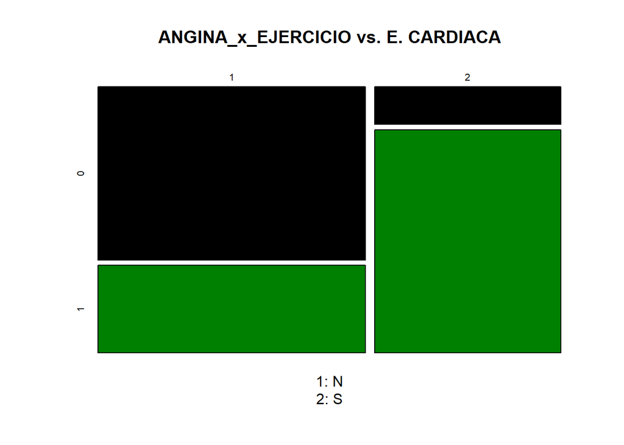

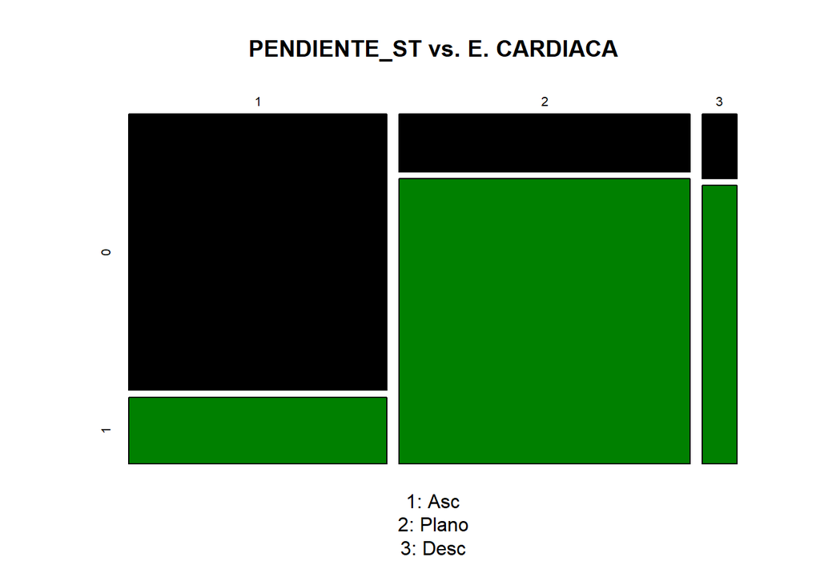

```r
# Analizamos las correlaciones de todos las caracteristicas de tipo categoricas con "E. CARDIACA"
# Lo añadimos a una tabla

datos_corr.Phi <- list()
datos_corr.CramerV <- list()
datos_corr.nombre <- list()

vector_tipos[8] <- "character"
vector_tipos[5] <- "character"

ind <- 1
ind_eti <- 1
for (i in colnames(datos_final))
{

  if(i != "E_CARDIACA")
  {
    tabla_cruzada <- table(as.numeric(unlist(datos_final[i])), datos_final$E_CARDIACA)
    datos_corr.CramerV <- append(datos_corr.CramerV, CramerV(tabla_cruzada))
    datos_corr.Phi <- append(datos_corr.Phi, Phi(tabla_cruzada))
    datos_corr.nombre <- append(datos_corr.nombre, i)
  }

  if (vector_tipos[ind] != 'numeric')
  {
    # Solo pintamos las variables categoricas ya que con las de tipo numerico no se aprecian los valores
    plot(tabla_cruzada,
         col = c("black","#008000"), xlab = vector_etiquetas[ind_eti],
         main = paste0(i, " vs. E. CARDIACA"))
    ind_eti = ind_eti + 1
  }

  ind <- ind + 1

}
```

```r
n_list <- list(nombre=as.character(datos_corr.nombre),
               CamerV=as.numeric(datos_corr.CramerV),
               Phi=as.numeric(datos_corr.Phi))

df_CramerV <- (as.data.frame(do.call(cbind, n_list)))
print(df_CramerV[order(df_CramerV$Phi, decreasing = TRUE),])
```

```
##                nombre            CamerV               Phi
## 11       PENDIENTE_ST 0.633914979247456 0.633914979247456
## 3    TIPO_DOLOR_TORAX 0.560309860170942 0.560309860170942
## 10            OLDPEAK 0.520727759286187 0.520727759286187
## 9  ANGINA_x_EJERCICIO 0.513768132124416 0.513768132124416
## 1                EDAD 0.404380273871888 0.404380273871888
## 8   FREC_CARDIACA_MAX 0.398095648097636 0.398095648097636
## 4    PRESION_ARTERIAL 0.331282489356957 0.331282489356957
## 2                SEXO 0.317570321818606 0.317570321818606
## 6     NIVEL_DE_AZUCAR 0.283413646865563 0.283413646865563
## 5          COLESTEROL  0.17862988864165  0.17862988864165
## 7       ECG_EN_REPOSO 0.115604279173622 0.115604279173622
```

### 4.3.2 Prueba de la V de Crámer

Valores de la V de Cramér (https://en.wikipedia.org/wiki/Cramér%27s_V) y Phi (https://en.wikipedia.org/wiki/Phi_coefficient) entre 0.1 y 0.3 nos indican que la asociación estadística es baja, y entre 0.3 y 0.5 se puede considerar una asociación media. Finalmente, si los valores fueran superiores a 0.5 la asociación estadística entre las variables sería alta.

Usaremos dichas variables para la obtención del Arbol de decisión, se podria utilizar un número mayor de variables, pero podría hacerse mucho complejo (con muchas reglas de decisión)

```r
# caracteristicas con significancia estadistica:
nombres_columnas <- df_CramerV$nombre[df_CramerV$Phi > 0.5]
nombres_columnas
```

```
## [1] "TIPO_DOLOR_TORAX"   "ANGINA_x_EJERCICIO" "OLDPEAK"
## [4] "PENDIENTE_ST"
```

### 4.3.3 Aplicación del modelo Decision Tree (Arbol de decisión)

```r
# Reducimos el datset
for(i in colnames(datos_final))
{
  if(!i %in% nombres_columnas)
  {
    if (!i == "E_CARDIACA")
    {
      datos_final$i <- NULL
    }
  }
}
```

Separamos conjunto de test y de entrenamiento con una proporción 33% Test 66% Training.

```r
set.seed(666)
y <- datos_final$E_CARDIACA # Variable objetivo
X <- datos_final[nombres_columnas] # Variables predictoras

split_prop <- 3
indexes = sample(1:nrow(X), size=floor(((split_prop-1)/split_prop)*nrow(X)))
train_X <- X[indexes,]
train_y <- y[indexes]
test_X <- X[-indexes,]
test_y <- y[-indexes]
```

Comprobamos que las variables train_y y test_y estén balanceadas reflejo de la variable y.

```r
print("y:")
```

```
## [1] "y:"
```

```r
summary(y)
```

```
##   0   1
## 366 446
```

```r
print("train_y:")
```

```
## [1] "train_y:"
```

```r
summary(train_y)
```

```
##   0   1
## 249 292
```

```r
print("test_y:")
```

```
## [1] "test_y:"
```

```r
summary(test_y)
```

```
##   0   1
## 117 154
```

Hacemos lo mismo con las variales train_crX y test_crX y X

```r
print("X:")
```

```
## [1] "X:"
```

```r
summary(X)
```

```
##  TIPO_DOLOR_TORAX ANGINA_x_EJERCICIO    OLDPEAK    PENDIENTE_ST
##  1:166            0:479              0      :336   0:359
##  2:195            1:333              1      : 78   1:405
##  3:451                               2      : 67   2: 48
##                                      1.5    : 49
##                                      3      : 27
##                                      1.2    : 23
##                                      (Other):232
```

```r
print("train_X:")
```

```
## [1] "train_X:"
```

```r
summary(train_X)
```

```
##  TIPO_DOLOR_TORAX ANGINA_x_EJERCICIO    OLDPEAK    PENDIENTE_ST
##  1:114            0:327              0      :227   0:246
##  2:129            1:214              1      : 49   1:260
##  3:298                               2      : 44   2: 35
##                                      1.5    : 35
##                                      3      : 18
##                                      1.2    : 15
##                                      (Other):153
```

```r
print("test_X:")
```

```
## [1] "test_X:"
```

```r
summary(test_X)
```

```
##  TIPO_DOLOR_TORAX ANGINA_x_EJERCICIO    OLDPEAK    PENDIENTE_ST
##  1: 52            0:152              0      :109   0:113
##  2: 66            1:119              1      : 29   1:145
##  3:153                               2      : 23   2: 13
##                                      1.5    : 14
##                                      3      :  9
##                                      1.2    :  8
##                                      (Other): 79
```

Se crea el árbol de decisión usando los datos de entrenamiento (no hay que olvidar que la variable outcome es de tipo factor):

```r
tree <- C50::C5.0(train_X, train_y, rules=TRUE )
summary(tree)
```

```
##
## Call:
## C5.0.default(x = train_X, y = train_y, rules = TRUE)
##
##
## C5.0 [Release 2.07 GPL Edition]      Mon Jan  9 11:41:43 2023
## -------------------------------
##
## Class specified by attribute `outcome'
##
## Read 541 cases (5 attributes) from undefined.data
##
## Rules:
##
## Rule 1: (160/7, lift 2.1)
##  TIPO_DOLOR_TORAX in {1, 2}
##  PENDIENTE_ST = 0
##  ->  class 0  [0.951]
##
## Rule 2: (193/20, lift 1.9)
##  OLDPEAK in {-1.1, -0.5, -0.1, 0, 0.2, 0.3, 0.4, 0.6, 0.7, 1.1, 1.2, 1.9,
##                     2.3, 3}
##  PENDIENTE_ST = 0
##  ->  class 0  [0.892]
##
## Rule 3: (140/15, lift 1.6)
##  TIPO_DOLOR_TORAX = 3
##  OLDPEAK in {-1, -0.7, 0.1, 0.5, 0.8, 0.9, 1, 1.4, 1.5, 1.6, 1.8, 2, 2.8}
##  ->  class 1  [0.887]
##
## Rule 4: (295/50, lift 1.5)
##  PENDIENTE_ST in {1, 2}
##  ->  class 1  [0.828]
##
## Default class: 1
##
##
## Evaluation on training data (541 cases):
##
##          Rules
##    ----------------
##      No      Errors
##
##       4   77(14.2%)   <<
##
##
##     (a)   (b)    <-classified as
##    ----  ----
##     193    56    (a): class 0
##      21   271    (b): class 1
##
##
##  Attribute usage:
##
##   94.09% PENDIENTE_ST
##   61.55% OLDPEAK
##   55.45% TIPO_DOLOR_TORAX
##
##
## Time: 0.0 secs
```

- Regla: 1 -> TIPO DE DOLOR DE TORAX con valores entre {1, 2} y PENDIENTE_ST <- 0 No tienen probabilidad de sufrir enfermadad cardiaca.
- Regla: 2 -> OLDPEAK entre {-1.1 y 3} con PENDIENTE_ST <- 0 No tienen probabilidad de sufrir Enfremedad Cardiaca.
- Regla: 3 -> TIPO_DOLOR_TORAX <- 3 y OLDPEAK entre {-1, 2.8} Tienen probabilidad de padecer enfermedad cardiaca.
- Regla: 4 -> PENDIENTE_ST entre {1,2} -> Tienen probabilidad de tener enfermedad cardiaca.

De manera más gráfica:

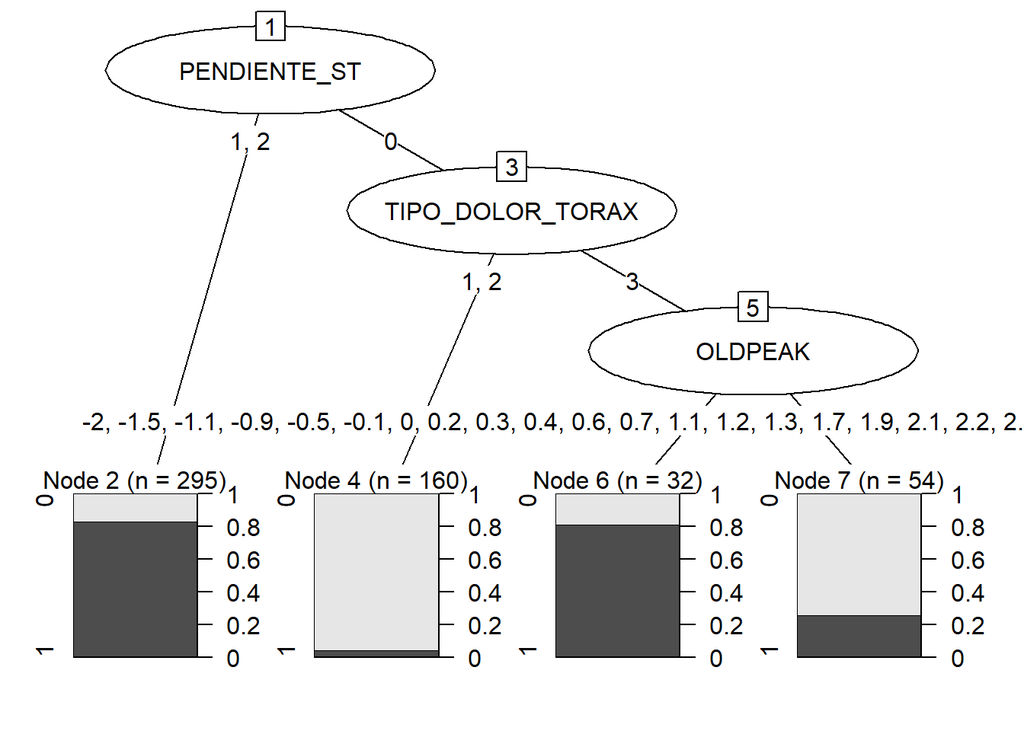

```r
model <- C50::C5.0(train_X, train_y)
plot(model)
```

### 4.3.4 Evaluación del modelo arbol de decision

Una vez tenemos el modelo, podemos comprobar su calidad prediciendo la clase para los datos de prueba que nos hemos reservado al principio.

```r
predicted_model <- predict( tree, test_X, type="class" )
print(sprintf("La precisión del árbol es: %.4f %%",100*sum(predicted_model == test_y) / length(predicted_model)))
```

```
## [1] "La precisión del árbol es: 83.7638 %"
```

Cuando hay pocas clases, la calidad de la predicción se puede analizar mediante una matriz de confusión que identifica los tipos de errores cometidos.

```r
mat_conf <- table(test_y, Predicted=predicted_model)
mat_conf
```

```
##       Predicted
## test_y   0   1
##      0  85  32
##      1  12 142
```

El modelo podria mejorarse sesgando a minimizar los falsos negativos, ya que no queremos que se nos escapen del diagnostico pacientes que puedan desarrollar una enfermedad cardiaca.

## 4.4 Random Forest

Nos interesa saber para las predicciones que variable son las que tienen más influencia. Así, probaremos con un enfoque algorítmico de Random Forest y obtendremos métricas de interpretabilidad con la librería IML (https://cran.r-project.org/web/packages/iml/iml.pdf). As:

```r
colnames(train_X)
```

```
## [1] "TIPO_DOLOR_TORAX"   "ANGINA_x_EJERCICIO" "OLDPEAK"
## [4] "PENDIENTE_ST"
```

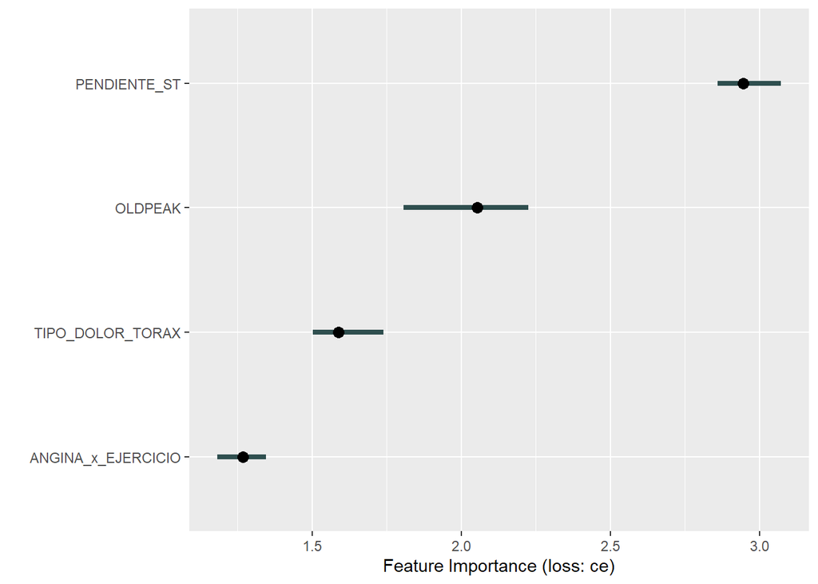

```r
train.data <- as.data.frame(cbind(train_X ,train_y))
colnames(train.data)[5] <- "E_CARDIACA"
rf <-  randomForest(E_CARDIACA ~ ., data = train.data, ntree = 50)

X <- train.data[which(names(train.data) != "E_CARDIACA")]
predictor <- Predictor$new(rf, data = X, y = train.data$E_CARDIACA)
imp <- FeatureImp$new(predictor, loss = "ce")
plot(imp)
```

```r
imp$results
```

```
##              feature importance.05 importance importance.95 permutation.error
## 1       PENDIENTE_ST      2.860714   2.946429      3.071429         0.3049908
## 2            OLDPEAK      1.807143   2.053571      2.225000         0.2125693
## 3   TIPO_DOLOR_TORAX      1.503571   1.589286      1.739286         0.1645102
## 4 ANGINA_x_EJERCICIO      1.182143   1.267857      1.346429         0.1312384
```

Podemos medir y graficar la importancia de cada variable para las predicciones del random forest con *FeatureImp*. La medida se basa funciones de pérdida de rendimiento que en nuestro caso será con el objetivo de clasificación (“ce”).

Precisión del modelo Random Forest

```r
# Extraido de la matriz de confusion
print(paste0("La precsión del modelo randomforest es: ",
             (as.numeric(rf$confusion[1,][1]) / (as.numeric(rf$confusion[1,][1]) +
                                                   as.numeric(rf$confusion[1,][2]))) * 100))
```

```
## [1] "La precsión del modelo randomforest es: 75.5020080321285"
```

Podemos observar el grado de importancia de las variables:

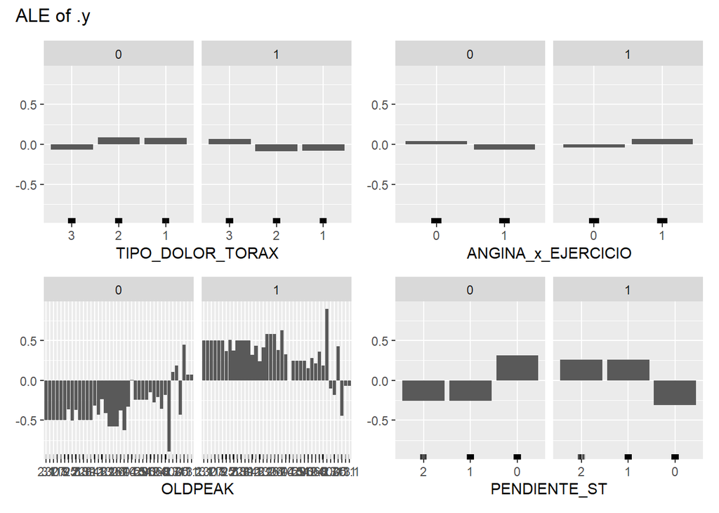

```r
X <- train.data[which(names(train.data) != "E_CARDIACA")]
predictor_cr <- Predictor$new(rf, data = X, y = train.data$E_CARDIACA)


effs <- FeatureEffects$new(predictor_cr)
plot(effs)
```

Podemos verlo de manera textual utilizando MeanDecreaseGini (Disminución media de GINI):

```r
rf$importance
```

```
##                    MeanDecreaseGini
## TIPO_DOLOR_TORAX           42.92313
## ANGINA_x_EJERCICIO         21.40851
## OLDPEAK                    47.57807
## PENDIENTE_ST               79.24776
```

Con este método obtenemos de nuevo PENDIENTE_ST con la variable más significativa.

Otros modelos basados en arboles de decision:

```r
tree_2 <- rpart(formula = train_y ~ ., data = train_X)
tree_2
```

```
## n= 541
##
## node), split, n, loss, yval, (yprob)
##       * denotes terminal node
##
##  1) root 541 249 1 (0.46025878 0.53974122)
##    2) PENDIENTE_ST=0 246  47 0 (0.80894309 0.19105691)
##      4) TIPO_DOLOR_TORAX=1,2 160   7 0 (0.95625000 0.04375000) *
##      5) TIPO_DOLOR_TORAX=3 86  40 0 (0.53488372 0.46511628)
##       10) OLDPEAK=0,0.2,0.3,0.6,1.2,2.3 54  14 0 (0.74074074 0.25925926) *
##       11) OLDPEAK=-1,-0.7,0.1,0.5,0.8,0.9,1,1.4,1.5,1.6,1.8,2,2.8 32   6 1 (0.18750000 0.81250000) *
##    3) PENDIENTE_ST=1,2 295  50 1 (0.16949153 0.83050847)
##      6) TIPO_DOLOR_TORAX=1,2 83  35 1 (0.42168675 0.57831325)
##       12) OLDPEAK=0.1,0.2,0.3,0.4,0.5,0.6,0.7,0.8,1,1.3,1.4,1.5,1.6,2.4,3,3.5 39  13 0 (0.66666667 0.33333333) *
##       13) OLDPEAK=0,1.2,1.7,1.8,2,2.2,2.5,2.6,2.9,3.6 44   9 1 (0.20454545 0.79545455) *
##      7) TIPO_DOLOR_TORAX=3 212  15 1 (0.07075472 0.92924528) *
```

Visualizamos el modelo:

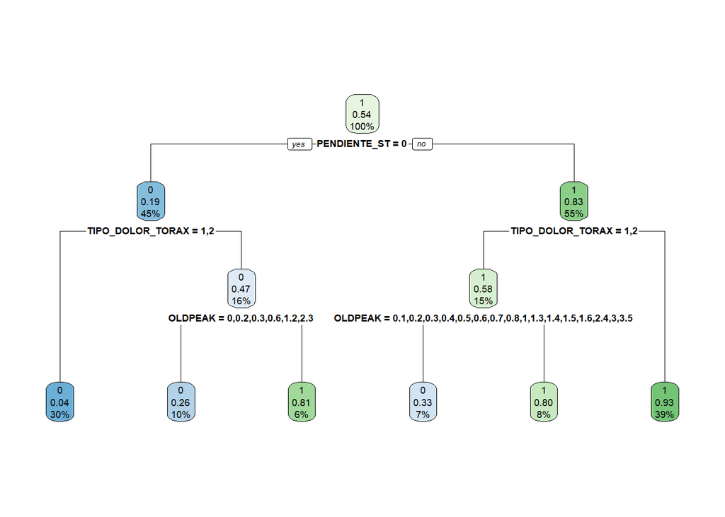

```r
rpart.plot(tree_2)
```

El modelo inicialmente se fija en la variable PENDIENTE_ST tanto como si es 0 como si es 1 se fija en TIPO_DOLOR_TORX (en cualquier caso se fija en los valores 1, 2 de dicha variable), después en funcion del rango de valores de OLDPEAK.

La probabilidades de sifrir enfermedad cardiaca son menores con PENDIENTE_ST=0, tanto en el caso en el que TIPO_DOLOR_TORAX esté en rango de valores de {1,2} al igual de que TIPO_DOLOR_TORAX no este en dicho rango, si se cumple que OLDPEAK esté en el rango {0-2.3}. En el otro caso habrá probabilidad alta de enfermedad cardiaca.

Para el caso de PENDIENTE_ST distinto a 0, y TIPO_DOLOR_TORAX en rango {1,2} si OLDPEAK está comprendido en rango {0-3.5} habrá pocas probabilidades de ENFERMEDAD CARDIACA, para los demás casos habrá altas probabilidades de enfermedad cardiaca.

# 5 Conclusiones

Tras realizar con el conjunto de datos distintas pruebas estadísticas y distintos modelos, nos damos cuenta de que todas las variables son necesarias para detectar enfermedades cardiacas. No obstante, dependiendo del modelo, no todas hay que usarlas.

Con los diversos modelos, hemos explorado distintas formas de predicción, como, por ejemplo, en las pruebas del modelo de regresión logística, los resultados de las pruebas han estado muy bien para comprobar las eficacia de dicho modelo. Por otro lado, los árboles de decisión la precisión también es muy buena.

En conclusión, con este análisis de datos se contestan las preguntas planteadas inicialmente, y se da unos modelos predictivos para detectar futuros casos.